# Eksempler på visualiseringer

pmd

Indlæs de nødvendige biblioteket

```r
library(tidyverse)
library(here)
library(ndjson)
library(xslt)
library(fs)
library(ggplot2)
library(readxl)
library(tidytext)

require(readr)  # for read_csv()
require(purrr)  # for map(), reduce()

source(here("src/p017-functions.R"))
```

# Indlæs data

## De konverterede skuespil

```r
read_plays_jsonl(here("test-data")) %>% select(filename, everything()) -> plays
```

## Indlæs Excelarket

```r
variants <- read_excel(here("Rolleliste.xlsx")) %>%
     unnest_tokens(variant, Alias, token = "regex", pattern = ", ") %>%
    mutate(
      Karakter = tolower(Karakter),
      variant = tolower(variant)
    )
```

```
* `` -> ...4
```

Kombiner skuespil og Excelark

```r
plays %>%
  mutate(speaker = tolower(speaker)) %>%
  left_join(variants, by = c("filename"="Filnavn", "speaker"="variant")) %>%
  mutate(speaker = if_else(!is.na(Karakter), Karakter, speaker)) %>%
  distinct -> plays
```

# Visualisering

Basalt set skal vi have implementeret en funktion á la `character_comparison_plot(<list of character names>, <list of character names>)`.

```r
# count words in "spoke"
plays %>%
  # remove rows that are not dialogue and empty speakers
  filter(!is.na(spoke), speaker != "") %>%

  # select only the columns, that we are interested in
  select(speaker, title, year, spoke) %>%

  # add the number of spoken words
  mutate(n_spoken_words = str_count(spoke, '\\w+')) %>%
  # remove the spoken words
  select(-spoke) %>%

  # group by title and speaker
  group_by(title, year, speaker) %>%

  # Sum the words spoken by each speaker in each play
  # Lastly store the new data frame in a new reference for later use
    summarise(words = sum(n_spoken_words), title, year) %>%
    ##    ungroup() %>%
  distinct() -> summary
summary %>%
    ungroup(speaker) %>%
    summarise(words_play = sum(words)) -> totals
summary %>%
  full_join(totals) %>%
    summarise(freq = words / words_play, speaker, title, year, words, words_play) %>%
    ungroup() -> summary
summary
```

| title | year | speaker | freq | words | words_play |
| --- | --- | --- | --- | --- | --- |
| Barselsstuen | (1724) | 1. advokat | 0.0074414110 | 154 | 20695 |
| Barselsstuen | (1724) | 1. dame | 0.0450350326 | 932 | 20695 |
| Barselsstuen | (1724) | 1. mand | 0.0006764919 | 14 | 20695 |
| Barselsstuen | (1724) | 1. officer | 0.0087460739 | 181 | 20695 |
| Barselsstuen | (1724) | 2. advokat | 0.0090359990 | 187 | 20695 |
| Barselsstuen | (1724) | 2. dame | 0.0281710558 | 583 | 20695 |
| Barselsstuen | (1724) | 2. mand | 0.0016912298 | 35 | 20695 |
| Barselsstuen | (1724) | 2. officer | 0.0213578159 | 442 | 20695 |
| Barselsstuen | (1724) | abelone | 0.0035274221 | 73 | 20695 |
| Barselsstuen | (1724) | ammen | 0.0022710800 | 47 | 20695 |

[output cut: 579 more lines]

```r
NA
```

## Sammenligning af enkelte karakterer

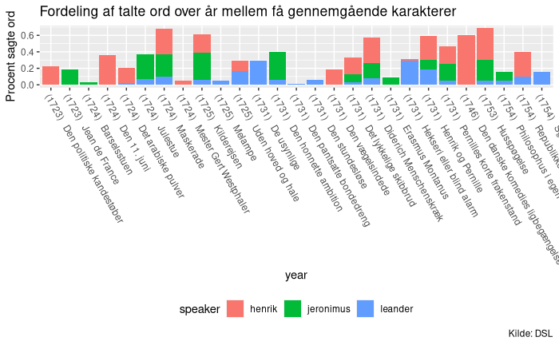

```r
  summary %>%
  #filter(speaker %in% c("henrik","pernille","troels")) %>%
  filter(speaker %in%   c("henrik", "jeronimus", "leander")) -> tmp
  #arrange(year) %>%

  #2 muligheder

  #add year to title
  tmp %>% mutate(title = paste(year," ",title)) %>%
  ggplot(aes(fill = speaker, y = freq, x = title)) +
    geom_bar(stat="identity") +
    theme(legend.position="bottom") +
    labs(
      title = "Fordeling af talte ord over år mellem få gennemgående karakterer",
      caption = "Kilde: DSL"
    ) +
  xlab("year") +
  ylab("Procent sagte ord") +
  theme(axis.text.x=element_text(angle = -60, hjust = 0))

      ggsave(here("graphs/pers-visualiseringer", "fordeling_talte_ord_v1.pdf"), width=16, height=9)
```

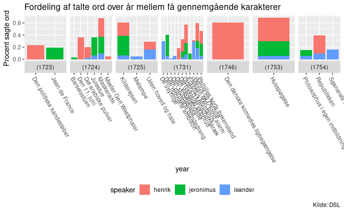

```r
  #use year as facet
  tmp %>%
  ggplot(aes(fill = speaker, y = freq, x = title)) +
    geom_bar(stat="identity") +
    theme(legend.position="bottom") +
    labs(
      title = "Fordeling af talte ord over år mellem få gennemgående karakterer",
      caption = "Kilde: DSL"
    ) +
  xlab("year") +
  ylab("Procent sagte ord") +
  facet_wrap(~year, scales = 'free_x', ncol=nrow(summary), switch="x") +
  theme(axis.text.x=element_text(angle = -60, hjust = 0))
    ggsave(here("graphs/pers-visualiseringer", "fordeling_talte_ord_v2.pdf"), width=16, height=9)
```

## Sammenligning af grupper af karakterer

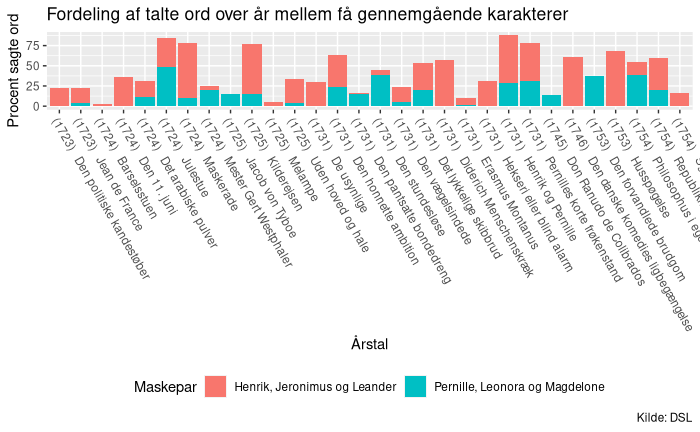

```r
group_1 <- c("henrik", "jeronimus", "leander")
group_2 <- c("pernille", "leonora", "magdelone")

summary %>%
  filter(speaker %in% c(group_1, group_2)) %>%
  mutate(gruppe = if_else(speaker %in% group_1, "Henrik, Jeronimus og Leander","Pernille, Leonora og Magdelone")) -> tmp2
  #filter(speaker %in% c("henrik","pernille","leonora")) %>%
  #arrange(year) %>%

  #2 muligheder

  #add year to title
  tmp2 %>% mutate(title = paste(year," ",title)) %>%
    ggplot(aes(fill = gruppe, y = freq*100, x = title)) +
    geom_bar(stat="identity") +
    theme(legend.position="bottom") +
    labs(
      title = "Fordeling af talte ord over år mellem få gennemgående karakterer",
      caption = "Kilde: DSL"
    ) +
  xlab("Årstal") +
  ylab("Procent sagte ord") +
  labs(fill='Maskepar') +
  theme(axis.text.x=element_text(angle = -60, hjust = 0))
        ggsave(here("graphs/pers-visualiseringer", "fordeling_talte_ord_grupper_v1.pdf"), width=16, height=9)
```

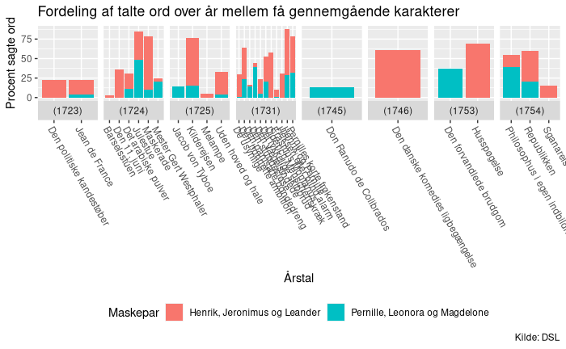

```r
  #use year as facet
  tmp2 %>%
    ggplot(aes(fill = gruppe, y = freq*100, x = title)) +
    geom_bar(stat="identity") +
    theme(legend.position="bottom") +
    labs(
      title = "Fordeling af talte ord over år mellem få gennemgående karakterer",
      caption = "Kilde: DSL"
    ) +
  xlab("Årstal") +
  ylab("Procent sagte ord") +
  labs(fill='Maskepar') +
  facet_wrap(~year, scales = 'free_x', ncol=nrow(summary), switch="x") +
  theme(axis.text.x=element_text(angle = -60, hjust = 0))
        ggsave(here("graphs/pers-visualiseringer", "fordeling_talte_ord_grupper_v2.pdf"), width=16, height=9)
```

```r
NA
NA
```

## Sortering efter år og/eller title

Indenfor statistik arbejder man med noget, som på engelsk hedder *factor*. Jeg mener, at det på dansk hedder faktor. Det er når man har en variabel eller observation, som kan tage værdier, der ikke er sorterbare i sog selv. Fx en farve. Her kan man så selv angive værdiernes rækkefølge.

Dette kan vi udnytte til sortering af titel. Jeg laver først en liste med alle de anvendte titler og sorterer den efter årstallet. Derefter omformer jeg titel kolonnen til en faktorvariabel og angiver der den rækkefølge som jeg fik fra sorteringen efter årstal.

```r
summary %>%
  filter(speaker %in%   c("henrik", "jeronimus", "leander")) %>%
  arrange(desc(year)) %>% # sortere lodret akse stigende efter årstal
  distinct(title) %>%
  pull(title) -> factor_levels_sort_year

summary %>%
  filter(speaker %in%   c("henrik", "jeronimus", "leander")) %>%
  distinct(title) %>%
  arrange(desc(title)) %>%  # Sortere lodret akse efter titel
  pull(title) -> factor_levels_sort_title

#summary$title_fct <- factor(summary$title, factor_levels)
```

## Sorter efter titel

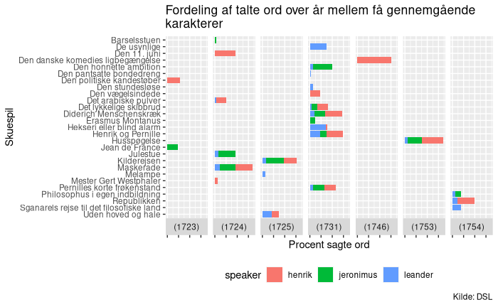

```r
summary %>%
  #filter(speaker %in% c("henrik","pernille","troels")) %>%
  filter(speaker %in%   c("henrik", "jeronimus", "leander")) %>%
  arrange(title) %>%
  ggplot(aes(fill = speaker, y = freq, x = factor(title, factor_levels_sort_title))) +
    geom_bar(stat="identity") +
    theme(legend.position="bottom") +
    labs(
      title = "Fordeling af talte ord over år mellem få gennemgående\nkarakterer",
      #subtitle = toupper("TEST"),
      caption = "Kilde: DSL"
    ) +
  xlab("Skuespil") +
  ylab("Procent sagte ord") +
  facet_wrap(~year, ncol=nrow(summary), switch="x") +
  theme(axis.text.x=element_blank()) +
  coord_flip() # flip the plot 90°
      ggsave(here("graphs/pers-visualiseringer", "fordeling_talte_ord_flip_v1.pdf"), width=16, height=9)
```

## Sorter efter år

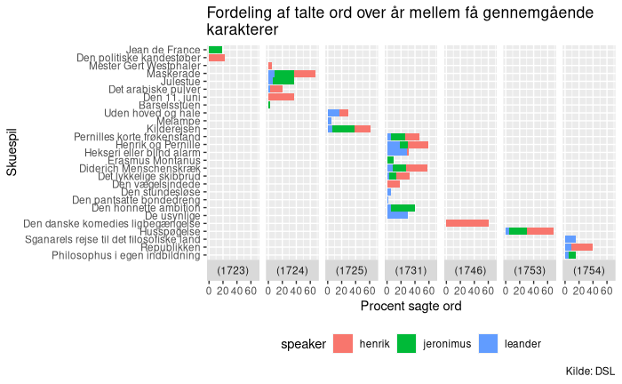

```r
summary %>%
  #filter(speaker %in% c("henrik","pernille","troels")) %>%
  filter(speaker %in%   c("henrik", "jeronimus", "leander")) %>%
  #arrange(year) %>%
  #mutate(title = str_c(title," ",year)) %>%
  ggplot(aes(fill = speaker, y = 100*freq, x = factor(title, factor_levels_sort_year))) +
    geom_bar(stat="identity") +
    theme(legend.position="bottom") +
    labs(
      title = "Fordeling af talte ord over år mellem få gennemgående\nkarakterer",
      #subtitle = toupper("TEST"),
      caption = "Kilde: DSL"
    ) +
  xlab("Skuespil") +
  ylab("Procent sagte ord") +
  facet_wrap(~year, ncol=nrow(summary), switch="x") +
  #theme(axis.text.x=element_blank()) +
  coord_flip()
      ggsave(here("graphs/pers-visualiseringer", "fordeling_talte_ord_flip_v2.pdf"), width=16, height=9)
```

## diagram uden opdeling på årstal

Først er vi nødt til at lave en ny faktor-erklæring for titel, da årstal nu skal inkluderes i denne.

```r
summary %>%
    ## filter(speaker %in%   c("henrik", "jeronimus", "leander")) %>%
    mutate(title_fct2 = str_c(title," ", year)) -> summary_with_yeartitle

summary_with_yeartitle %>%
    arrange(desc(year)) %>%
    distinct(title_fct2) %>%
    pull(title_fct2) -> factor_levels_2

factor_levels_2
```

```
 [1] "Philosophus i egen indbildning (1754)"           "Republikken (1754)"
 [3] "Sganarels rejse til det filosofiske land (1754)" "Den forvandlede brudgom (1753)"
 [5] "Husspøgelse (1753)"                              "Plutus (1753)"
 [7] "Den danske komedies ligbegængelse (1746)"        "Don Ranudo de Colibrados (1745)"
 [9] "De usynlige (1731)"                              "Den honnette ambition (1731)"
[11] "Den pantsatte bondedreng (1731)"                 "Den stundesløse (1731)"
[13] "Den vægelsindede (1731)"                         "Det lykkelige skibbrud (1731)"
[15] "Diderich Menschenskræk (1731)"                   "Erasmus Montanus (1731)"
[17] "Hekseri eller blind alarm (1731)"                "Henrik og Pernille (1731)"
[19] "Pernilles korte frøkenstand (1731)"              "Jacob von Tyboe (1725)"
[21] "Kilderejsen (1725)"                              "Melampe (1725)"
[23] "Uden hoved og hale (1725)"                       "Ulysses von Ithacia (1725)"
[25] "Barselsstuen (1724)"                             "Den 11. juni (1724)"
[27] "Det arabiske pulver (1724)"                      "Julestue (1724)"
[29] "Maskerade (1724)"                                "Mester Gert Westphaler (1724)"
[31] "Den politiske kandestøber (1723)"                "Den vægelsindede (1723)"
[33] "Jean de France (1723)"                           "Jeppe på Bjerget (1723)"
[35] "Mester Gert Westphaler (1723)"                   "Nytårsprolog til en komedie (1723)"
```

```r
summary_with_yeartitle %>%
    mutate(title_fct2 = factor(title_fct2, factor_levels_2)) -> summary_fct2

summary_fct2 %>% select(title_fct2)
```

| title_fct2 |
| --- |
| Barselsstuen (1724) |
| Barselsstuen (1724) |
| Barselsstuen (1724) |
| Barselsstuen (1724) |
| Barselsstuen (1724) |
| Barselsstuen (1724) |
| Barselsstuen (1724) |
| Barselsstuen (1724) |
| Barselsstuen (1724) |
| Barselsstuen (1724) |

[output cut: 579 more lines]

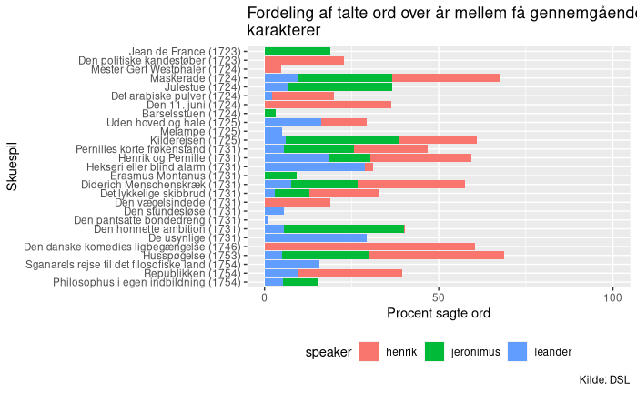

```r
summary_fct2 %>%
    ## filter(speaker %in% c("henrik","pernille","troels")) %>%
    filter(speaker %in%   c("henrik", "jeronimus", "leander")) %>%
    ggplot(aes(fill = speaker, y = 100*freq, x = title_fct2)) +
       geom_bar(stat="identity") +
       theme(legend.position="bottom") +
       labs(
           title = "Fordeling af talte ord over år mellem få gennemgående\nkarakterer",
           ## subtitle = toupper("TEST"),
           caption = "Kilde: DSL"
       ) +
    scale_y_continuous(limits = c(0,100), breaks = c(0,50,100)) +
    xlab("Skuespil") +
    ylab("Procent sagte ord") +
    coord_flip()
      ggsave(here("graphs/pers-visualiseringer", "fordeling_talte_ord_flip_v3.pdf"), width=16, height=9)
```

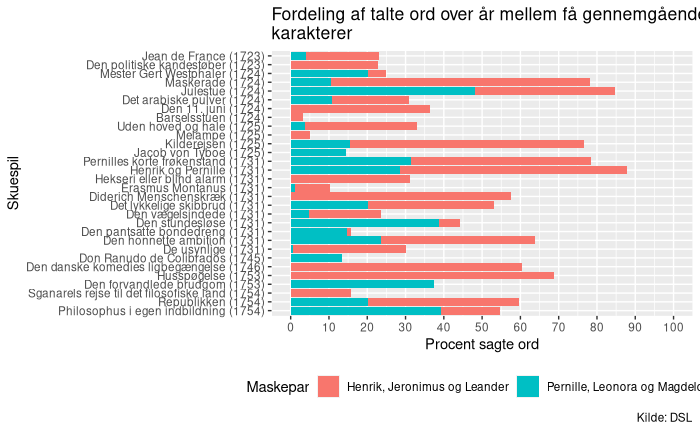

```r
group_1 <- c("henrik", "jeronimus", "leander")
group_2 <- c("pernille", "leonora", "magdelone")

summary_fct2 %>%
    filter(speaker %in% c(group_1, group_2)) %>%
    mutate(gruppe = if_else(speaker %in% group_1, "Henrik, Jeronimus og Leander","Pernille, Leonora og Magdelone")) %>%
    ## filter(speaker %in%   c("henrik", "jeronimus", "leander")) %>%
    ggplot(aes(fill = gruppe, y = 100*freq, x = title_fct2)) +
       geom_bar(stat="identity") +
       theme(legend.position="bottom") +
       labs(
           title = "Fordeling af talte ord over år mellem få gennemgående\nkarakterer",
           ## subtitle = toupper("TEST"),
           caption = "Kilde: DSL"
       ) +
    scale_y_continuous(limits = c(0,100), breaks = c(0,10,20,30,40,50,60,70,80,90,100)) +
    xlab("Skuespil") +
    ylab("Procent sagte ord") +
      labs(fill='Maskepar') +
    coord_flip()
      ggsave(here("graphs/pers-visualiseringer", "fordeling_talte_ord_flip_grupper.pdf"), width=16, height=9)
```

## Let’s Go Crazy

Herefter følger eksempler på, hvordan man benytter forskellige ggplot temaer.

Først et lidt pjattet eksempel, som dog viser bredden af tematiske muligheder.

Inden nedenstående `tvthemes` kan indlæses, skal det først installeres. Dette skal kun gøre én gang:

```r
#install.packages("tvthemes")
```

```r
library(tvthemes)
```

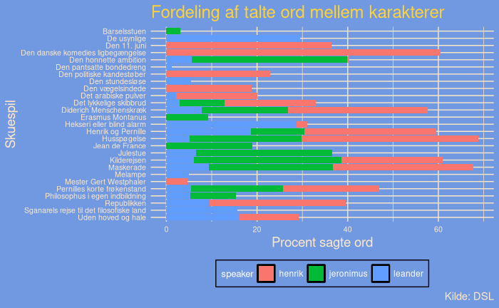

```r
summary %>%
  #filter(speaker %in% c("henrik","pernille","troels")) %>%
  filter(speaker %in%   c("henrik", "jeronimus", "leander")) %>%
  #arrange(year) %>%
  ggplot(aes(fill = speaker, y = 100*freq, x = fct_rev(title))) +
    geom_bar(stat="identity") +
    theme_simpsons(
      #title.font = "Akbar",
      #text.font = "Akbar",
      axis.text.size = 8) +
    theme(legend.position="bottom") +
    labs(
      title = "Fordeling af talte ord mellem karakterer",
      #subtitle = toupper("TEST"),
      caption = "Kilde: DSL"
    ) +
  xlab("Skuespil") +
  ylab("Procent sagte ord") +
  #facet_wrap(~year, ncol=nrow(summary), switch="x") +
  #theme(axis.text.x=element_blank()) +
  coord_flip()
      ggsave(here("graphs/pers-visualiseringer", "fordeling_talte_ord_tema_simpsons.pdf"), width=16, height=9)
```

## Mere anvendelige eksempler

I de næste eksempler, starter jeg med at lægge plottet over i variablen `p`. Derefter kan jeg så nemt plotte først uden fordeling på år og efterfølgende med fordeling på år.

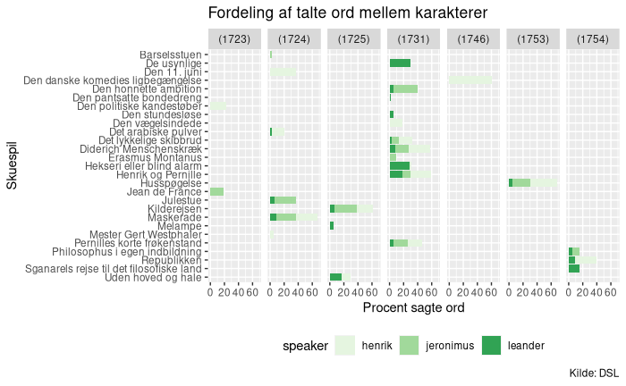

```r
summary %>%
  #filter(speaker %in% c("henrik","pernille","troels")) %>%
  filter(speaker %in%   c("henrik", "jeronimus", "leander")) %>%
  arrange(year) %>%
  ggplot(aes(fill = speaker, y = 100*freq, x = factor(title, factor_levels_sort_title))) +
    geom_bar(stat="identity") +
    theme(legend.position="bottom") +
    labs(
      title = "Fordeling af talte ord mellem karakterer",
      #subtitle = toupper("TEST"),
      caption = "Kilde: DSL"
    ) +
  xlab("Skuespil") +
  ylab("Procent sagte ord") +
  scale_fill_brewer(type = "seq", palette = "Greens") -> p # VÆLG GRØN PALETTE

p + coord_flip() +
  facet_wrap(~year, ncol=nrow(summary), strip.position="top")
      ggsave(here("graphs/pers-visualiseringer", "fordeling_talte_ord_greens.pdf"), width=16, height=9)
```

## Viridis

Install skal kun køres første gang, denne notebook gennemgås.

```r
library("viridis")
```

```r
library(viridis)
```

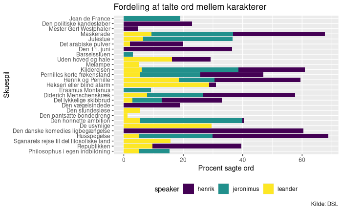

```r
summary %>%
  #filter(speaker %in% c("henrik","pernille","troels")) %>%
  filter(speaker %in%   c("henrik", "jeronimus", "leander")) %>%
  arrange(year) %>%
  ggplot(aes(fill = speaker, y = 100*freq, x = factor(title, factor_levels_sort_year))) +
    geom_bar(stat="identity") +
    theme(legend.position="bottom") +
    labs(
      title = "Fordeling af talte ord mellem karakterer",
      #subtitle = toupper("TEST"),
      caption = "Kilde: DSL"
    ) +
  xlab("Skuespil") +
  ylab("Procent sagte ord") +
  scale_fill_viridis(discrete = TRUE) +
  coord_flip() -> p

p
      ggsave(here("graphs/pers-visualiseringer", "fordeling_talte_ord_viridis_v1.pdf"), width=16, height=9)
```

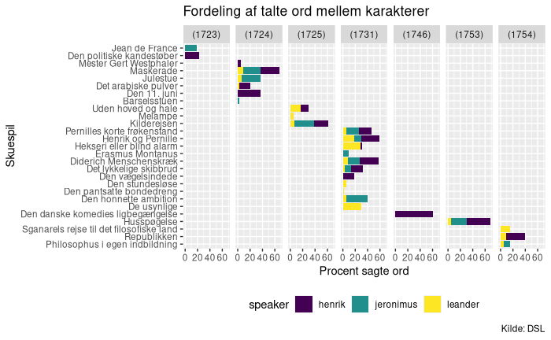

```r
p + facet_wrap(~year, ncol=nrow(summary), strip.position="top")
      ggsave(here("graphs/pers-visualiseringer", "fordeling_talte_ord_viridis_v2.pdf"), width=16, height=9)
```

## Economist

Installation af `ggthemes` skal kun foretages første gang denne notebook gennemgås.

```r
#install.packages("ggthemes")
```

```r
library(ggthemes)
```

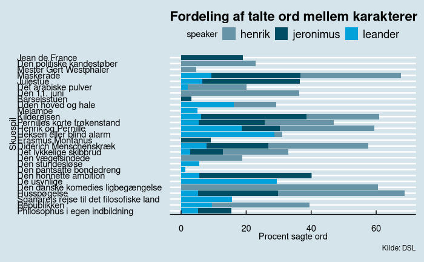

```r
summary %>%
  #filter(speaker %in% c("henrik","pernille","troels")) %>%
  filter(speaker %in%   c("henrik", "jeronimus", "leander")) %>%
  arrange(year) %>%
  ggplot(aes(fill = speaker, y = 100*freq, x = factor(title, factor_levels_sort_year))) +
    geom_bar(stat="identity") +
    theme(legend.position="bottom") +
    labs(
      title = "Fordeling af talte ord mellem karakterer",
      #subtitle = toupper("TEST"),
      caption = "Kilde: DSL"
    ) +
  xlab("Skuespil") +
  ylab("Procent sagte ord") +
  #scale_fill_brewer(palette = "Greens") +
  theme_economist() + scale_fill_economist() +
  coord_flip() -> p

p
      ggsave(here("graphs/pers-visualiseringer", "fordeling_talte_ord_tema_economist_v1.pdf"), width=16, height=9)
```

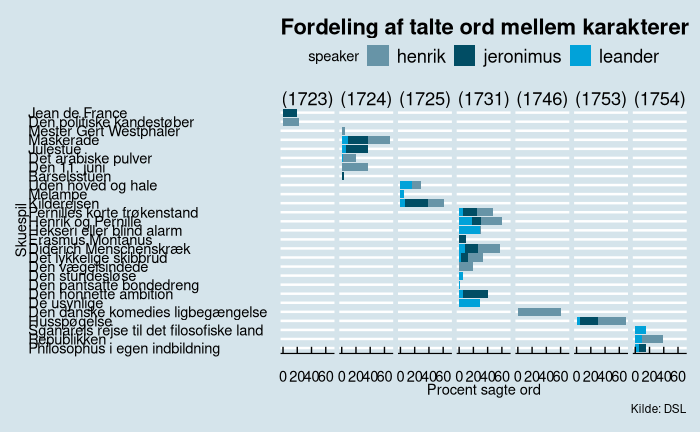

```r
p + facet_wrap(~year, ncol=nrow(summary), strip.position="top")
      ggsave(here("graphs/pers-visualiseringer", "fordeling_talte_ord_tema_economist_v2.pdf"), width=16, height=9)
```

## Minimal

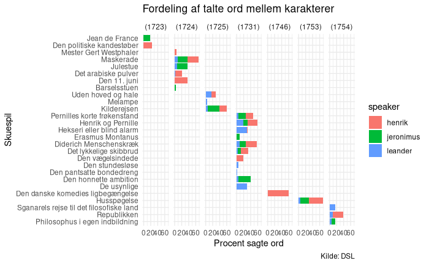

```r
summary %>%
  #filter(speaker %in% c("henrik","pernille","troels")) %>%
  filter(speaker %in%   c("henrik", "jeronimus", "leander")) %>%
  arrange(year) %>%
  ggplot(aes(fill = speaker, y = 100*freq, x = factor(title, factor_levels_sort_year))) +
    geom_bar(stat="identity") +
    theme(legend.position="bottom") +
    labs(
      title = "Fordeling af talte ord mellem karakterer",
      #subtitle = toupper("TEST"),
      caption = "Kilde: DSL"
    ) +
  xlab("Skuespil") +
  ylab("Procent sagte ord") +
  #scale_fill_brewer(palette = "Greens") +
  facet_wrap(~year, ncol=nrow(summary), strip.position = "top") +
  #theme(axis.text.x=element_blank()) +
  coord_flip() +
  #theme_bw()
  theme_minimal()
      ggsave(here("graphs/pers-visualiseringer", "fordeling_talte_ord_tema_minimal.pdf"), width=16, height=9)
```

## Gruppesammenligning igen

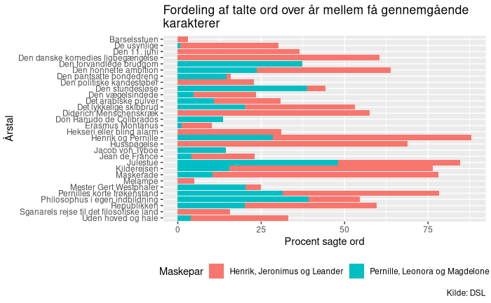

```r
group_1 <- c("henrik", "jeronimus", "leander")
group_1_name <- "Henrik, Jeronimus og Leander"

group_2 <- c("pernille", "leonora", "magdelone")
group_2_name <- "Pernille, Leonora og Magdelone"

summary %>%
  filter(!is.na(title)) %>%
  filter(speaker %in% c(group_1, group_2)) %>%
  mutate(gruppe = if_else(speaker %in% group_1, group_1_name,group_2_name)) %>%
  ggplot(aes(fill = gruppe, y = freq*100, x = fct_rev(title))) +
    geom_bar(stat="identity") +
    theme(legend.position="bottom") +
    labs(
      title = "Fordeling af talte ord over år mellem få gennemgående\nkarakterer",
      #subtitle = toupper("TEST"),
      caption = "Kilde: DSL"
    ) +
  xlab("Årstal") +
  ylab("Procent sagte ord") +
  labs(fill='Maskepar') +
  coord_flip()
      ggsave(here("graphs/pers-visualiseringer", "fordeling_talte_ord_grupper_igen.pdf"), width=16, height=9)
```

# Farvelægning

Dette afsnit beror på at `summary_fct2` er beregner tidligere.

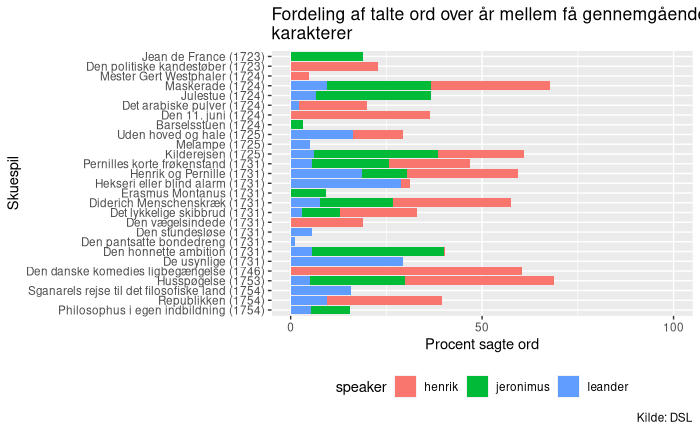

```r
summary_fct2 %>%
    ## filter(speaker %in% c("henrik","pernille","troels")) %>%
    filter(speaker %in%   c("henrik", "jeronimus", "leander")) %>%
    ggplot(aes(fill = speaker, y = 100*freq, x = title_fct2)) +
       geom_bar(stat="identity") +
       theme(legend.position="bottom") +
       labs(
           title = "Fordeling af talte ord over år mellem få gennemgående\nkarakterer",
           ## subtitle = toupper("TEST"),
           caption = "Kilde: DSL"
       ) +
    scale_y_continuous(limits = c(0,100), breaks = c(0,50,100)) +
    xlab("Skuespil") +
    ylab("Procent sagte ord") +
    coord_flip()
```

Nu vil vi så angive vores egne farver for Henrik, Jeronimus og Leander.

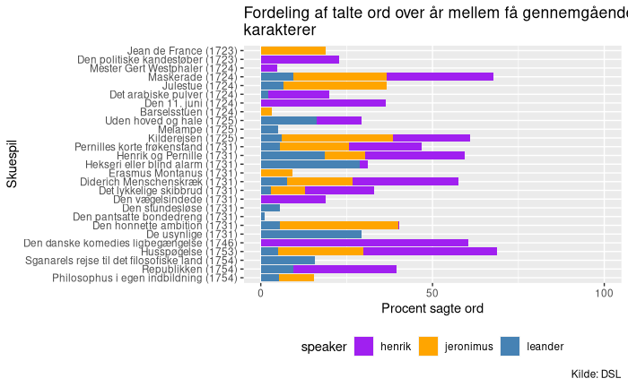

```r
summary_fct2 %>%
    filter(speaker %in%   c("henrik", "jeronimus", "leander")) %>%
    ggplot(aes(fill = speaker, y = 100*freq, x = title_fct2)) +
       geom_bar(stat="identity") +
       theme(legend.position="bottom") +
       labs(
           title = "Fordeling af talte ord over år mellem få gennemgående\nkarakterer",
           ## subtitle = toupper("TEST"),
           caption = "Kilde: DSL"
       ) +
      scale_fill_manual(
        values = c(
          "henrik" = "purple",
          "jeronimus" = "orange",
          "leander"="steelblue"
        )
      ) +
    scale_y_continuous(limits = c(0,100), breaks = c(0,50,100)) +
    xlab("Skuespil") +
    ylab("Procent sagte ord") +
    coord_flip()
```

# Gemme en visualisering som liggende A4 PDF

```r
ggsave(here("graphs/pers-visualiseringer", "ng3.pdf"),
       width = 297,
       height = 210,
       units = "mm")
```